# HW04 Part 1: Complete Chapter 3

Hayley Laubinger

11 July 2020

## Chapter 3

- change “your name” in the YAML header above your name.

### Section 3.1

- Load tidyverse packages. I’ve entered the first code chunk for you. ** you must enter all subsequent chucks and run the code.**

```r
library("tidyverse")
```

- If you get an error, then you did not install the `tidyverse` package like you were supposed to in the previous assignment. Go back to that assignment and complete that step. (This should not be the case, though.)

### Section 3.2 First Steps

Enter your code chunks for section 3.2 here. Get in the habit of entering a brief description of what each chunk of code does. Enter this above the chunk. like I did in Section 3.1.

### Section 3.2.2 Creating a ggplot

## A plot that shows the negative relationships between engine size and fuel effciency

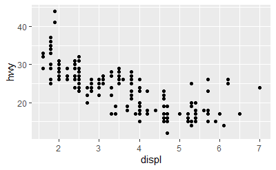

```r
ggplot(data = mpg) +
  geom_point(mapping = aes(x = displ, y = hwy))
```

The scatterplot shows the negative relationship between engine size and the fuel efficiency.

#### Section 3.2 Questions

Answer the questions *completely.* Some answers will require you to write code in a code chunk and also to type text before or after the chunk. Other answers will require only code or only text.

**1:** Run ggplot(data = mpg). What do you see?

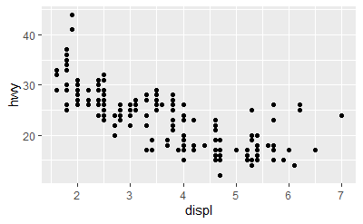

```r
ggplot(data = mpg) +
  geom_point(mapping = aes(x = displ, y = hwy))
```

This shows the relationship between fuel efficiency with engine displacement vs highway fuel economy on a scatterplot

**2:** How many rows are in `mpg`? How many columns? **Hint:** Use the `dim()` function. Type `dim()` in the console to learn what `dim()` does.

## display arrangement of mpg

```r
dim(mpg)
```

```
[1] 234  11
```

Mpg has 234 rows and 11 columns.

**3:** What does the `drv` variable describe? Read the help for `?mpg` to find out.

The ‘drv’ variable describes the vechicles drive train. The 4=4 wheel drive, f=front wheel drive, r= rear wheel drive.

**4:** Make a scatterplot of `hwy` vs `cyl`. ## A scatterplot of ‘hwy’ vs ‘cyl’.

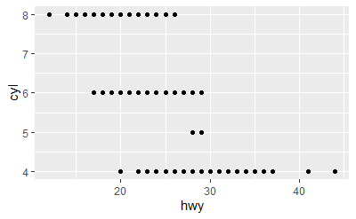

```r
ggplot(data = mpg) +
  geom_point(mapping = aes(x = hwy, y = cyl))
```